# STAT 240 Final Project Draft

Group: 5

Names: Vasudha Khanna, Tovah Frockt, Pranav Dronavalli, Leo Liu

## Background

The stock markets are venues for buyers and sellers to meet to exchange equity shares of public corporations. These equity shares or stocks represents fractional ownership of equity in an organization. Stocks can be traded individually and in groups. The stock values are denoted twice daily and these are called the “opening price” and “closing price” of these stocks. There are multiple factors that influence the stability and volatility of these stocks around the world.

Some factors affecting stock values are:  
- news releases on earnings and profits, and future estimated earnings.  
- announcement of dividends.  
-introduction of a new product or a product recall.  
-securing a new large contract.  
- employee layoffs.  
- anticipated takeover or merger.  
- a change of management.  
- accounting errors or scandals.

Since these stocks values are so volatile, investors need to research the past performance and reliability of the different stock markets to predict it’s future performance for lucrative returns. The stock markets of each country differ from one another based on a variety of factors. One factor is how much control the governments’ have over the market and what policy or administrative mechanisms a government can use to instill trust in the market. No country wants to have a volatile market because that doesn’t attract investors, thus depending on the nature of the government, some countries have tighter controls on how much the market can swing in a given amount of time.

[^2]

Key Variables are:

| Variable | Description |
| --- | --- |
| Index | Ticker symbol for the stock market |
| Year | Year |
| Month | Month |
| Open | Opening price of the market |
| High | Highest price of the day in the market |
| Close | Closing price of the market |
| Low | Lowest price of the day in the market |

The report will assess how the different markets have performed over the years and which market has been most stable over the course of these years. We find that for the stock market of most countries, the average closing price for month to month, does not change more than the average difference.

## Initial Observations

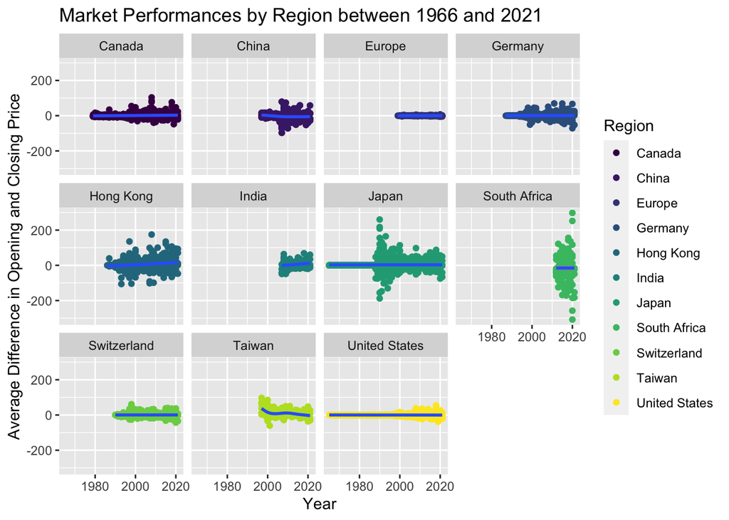

## Analysis

| Region | Successes | Total | ExpectedValue | Pvalue |
| --- | --- | --- | --- | --- |
| Canada | 448 | 504 | 378.00 | 5.564256e-08 |
| China | 340 | 574 | 430.50 | 5.772286e-08 |
| Europe | 218 | 259 | 194.25 | 4.220336e-04 |
| Germany | 315 | 402 | 301.50 | 1.340582e-01 |
| Hong Kong | 329 | 414 | 310.50 | 3.571011e-02 |
| India | 115 | 165 | 123.75 | 1.260837e-01 |
| Japan | 593 | 678 | 508.50 | 5.519518e-08 |
| South Africa | 97 | 112 | 84.00 | 4.249919e-03 |
| Switzerland | 303 | 367 | 275.25 | 7.079477e-04 |
| Taiwan | 209 | 287 | 215.25 | 4.132617e-01 |
| United States | 1204 | 1270 | 952.50 | 8.442921e-08 |

Our hypothesis test aimed to measure the average stock market stability for each country. We chose a binomial distribution because there were not enough observations for each country for us to use a continuous normal distribution. The discrete nature of opening and closing prices encourages the use of a binomial distribution. Our null hypothesis is that in any given month in a particular country, there is a 75% chance that month will fall in our range of stability. We define stability as within a 0.25% of the average opening price divided by the average closing price of the month. Our test statistic is the amount of months that are stable.

According to our hypothesis test, Germany, India, and Taiwan have stock markets have a 75% chance of being stable during any given month. According to our hypothesis test, Canada, China, Europe, Hong Kong, Japan, South Africa, Switzerland, and the United States do not support a the null hypothesis that there is a 75% chance of stability within a given month. To illustrate this graphically, we have included one graph from Germany (considered stable, accepting the null hypothesis) and one graph from China (considered unstable, rejecting the null hypothesis). The dashed vertical lines on each graph represent the distance from the mean in the binomial distribution. The dashed lines indicate the value for which every point in the tails that are more extreme or less extreme than the test-statistic. Every point to the left or right of the dashed lines, in the tails, are values that are more extreme. For Germany, the red dashed line represents the number of months that are stable from the sample size, where we accept our null hypothesis of stability. For China, the red dashed line represents the number of months that are stable from the sample size, where we reject our null hypothesis of stability.

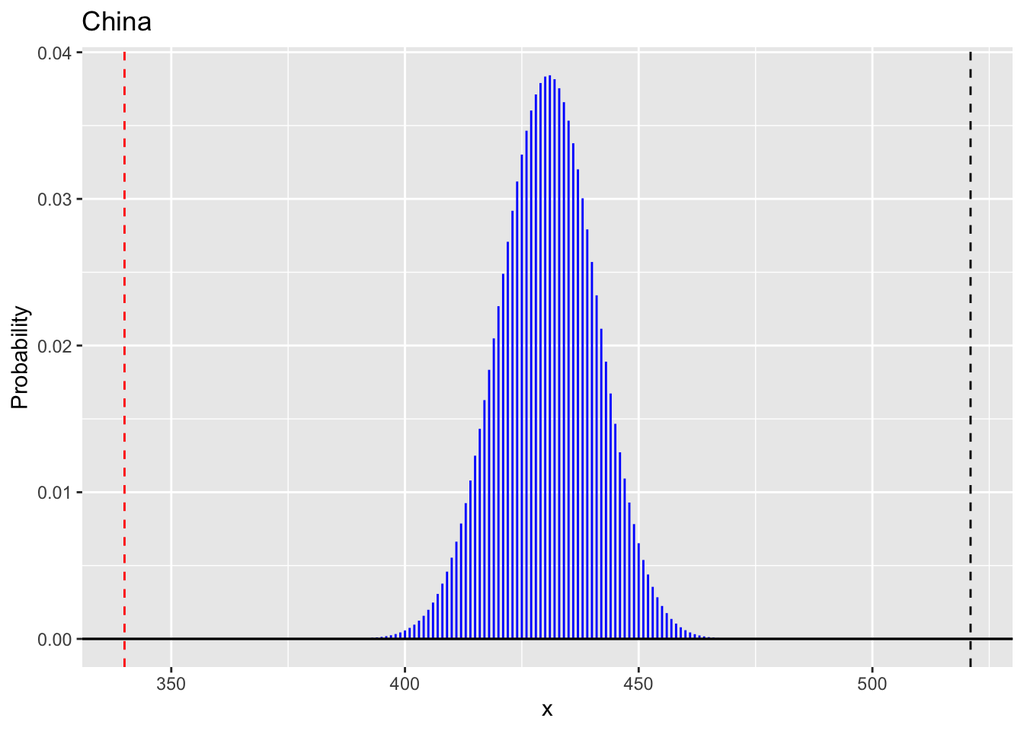

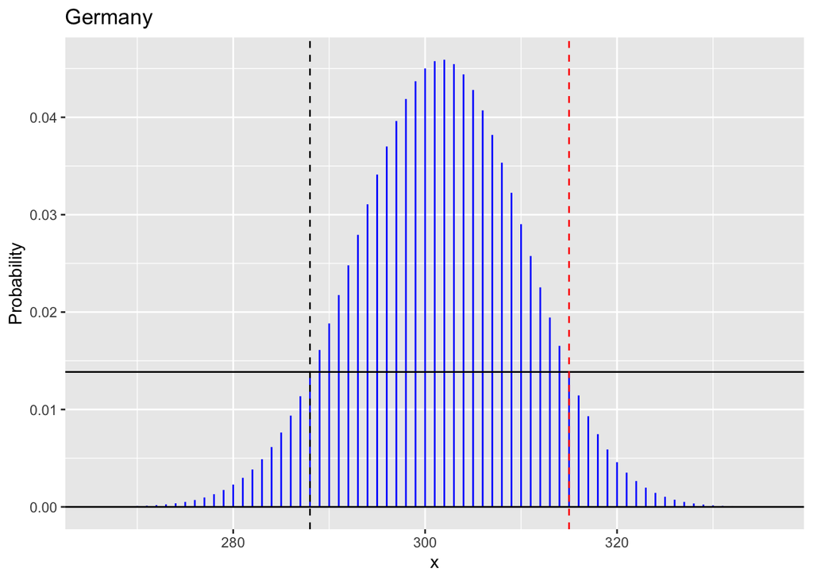

## Discussion

Potential shortcomings of our analysis does not include government mechanisms for stabilizing the stock market in their respective countries. This means that our observations are only based on raw data. We chose a narrow definition of stability in our project. Other people may define stability as either higher or lower than we did, which would impact their analysis. In our analysis, we kept our outliers because they are good for our definition of stability. In our definition of stability, we want the outliers because they give instances of the market being unstable. Removing outliers could skew our data to make markets look more stable than they actually are. In our definition of stability there are potential drawbacks. We defined stability after looking at our data and as a monthly basis rather than a daily basis. Defining stability as a monthly number could potentially make markets seem more stable than they are, on a daily basis there are days with extreme gains and extreme losses.

Future directions for additional work could include looking at the average difference in daily stock market prices rather than monthly prices. This additional analysis could be helpful in determining stability over shorter, more discrete periods of time. A new question using our methodology could be analyzing the stability of a particular stock in a given market. Using our framework, one could see which stocks are most and least stable in a given market based on daily opening and closing prices of that stock. A different approach is redefining how we measured stability. In a new method, we could define stability as increasing or decreasing by less than 5% of the previous months’ average closing price.

References

[^1]: https://finance.yahoo.com/quote/YHOO/history?ltr=1
[^2]: https://www.kaggle.com/datasets/mattiuzc/stock-exchange-data?resource=d ownload&select=indexInfo.csv.